# Imputation des données manquantes

Pour les attributs S', 'TEMPERATURE', 'S_M8_APPETIT', 'S_FATIGUE', 'S_ARTHRALGI', 'S_T_DIGESTIF', 'S_VERTIGE', 'S_FRISSON', 'S_MYALGIE', 'S_DIARRHEE', 'S_DABDO', 'S_VOMISS', 'S_NAUSEE', 'S_CEPHALE'et 'S_FIEVRE' nous avons mis 1 si le patient presente le signe ou le symptome et 0 si le patient ne presnte pas le signe ou le symptome Pour l'attribut Diagnostic nous avons mis 1 si un patient est atteint de n'importe quel type de paludisme et 0 si le patient n'est pas atteint de paludisme. Ceci nous permettra de faire une regression logistique sur nos données

```python
import pandas as pd
import numpy as np
from sklearn import preprocessing
import matplotlib.pyplot as plt
plt.rc("font", size=14)
from sklearn.linear_model import LogisticRegression
from sklearn.cross_validation import train_test_split
import seaborn as sns
sns.set(style="white")
sns.set(style="whitegrid", color_codes=True)
```

```python
palu=pd.read_excel('C://Users//ndogue/Documents/palu_impute001.xlsx')
```

```python
palu.head()
```

|  | Num_Patients | Num_JourVisite | A_annees | A_mois | A_semaines | A_jours | Sexe | TENSION_A 1 | TENSION_A 2 | PPOIDS | ... | S_DABDO | S_VOMISS | S_NAUSEE | S_CEPHALE | S_FIEVRE | TDR | Diagnostic | Hosp | Ref | Deces |
| --- | --- | --- | --- | --- | --- | --- | --- | --- | --- | --- | --- | --- | --- | --- | --- | --- | --- | --- | --- | --- | --- |
| 0 | 1 | 0 | 20 | 0 | 0 | 0 | 2 | 11 | 7 | 74 | ... | 0 | 1 | 0 | 0 | 0 | 9 | 0 | 9 | 9 | 9 |
| 1 | 2 | 1 | 7 | 0 | 0 | 0 | 1 | 12 | 7 | 113 | ... | 0 | 0 | 0 | 1 | 0 | 2 | 0 | 9 | 9 | 9 |
| 2 | 3 | 2 | 44 | 0 | 0 | 0 | 2 | 8 | 7 | 98 | ... | 0 | 0 | 0 | 1 | 1 | 9 | 0 | 9 | 9 | 9 |
| 3 | 4 | 3 | 2 | 6 | 0 | 0 | 1 | 11 | 8 | 85 | ... | 0 | 0 | 0 | 0 | 0 | 2 | 0 | 2 | 2 | 2 |
| 4 | 5 | 4 | 31 | 0 | 0 | 0 | 1 | 10 | 7 | 71 | ... | 0 | 0 | 0 | 0 | 0 | 9 | 0 | 9 | 9 | 9 |

5 rows × 29 columns

```python
print(palu.shape)
print(list(palu.columns))
```

[output not shown]

```python
#  Barplot pour la variable dépendante Diagnostic
```

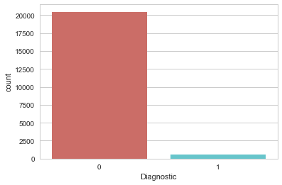

```python
sns.countplot(x=palu['Diagnostic'],data=palu, palette='hls')
plt.show()
```

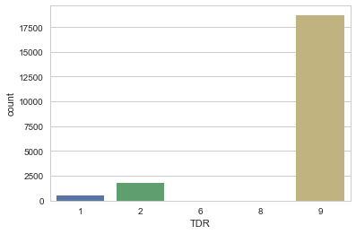

```python
sns.countplot(x=palu['TDR'], data=palu)
plt.show()
```

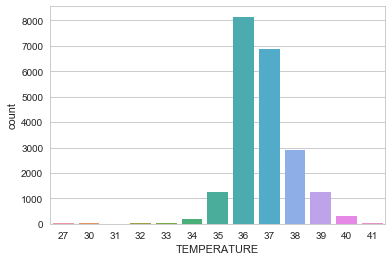

```python
sns.countplot(x=palu['TEMPERATURE'], data=palu)
plt.show()
```

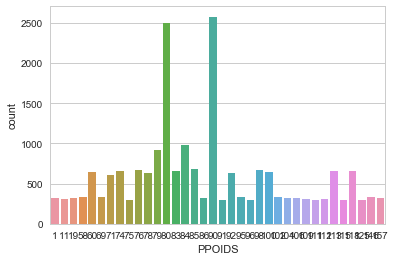

```python
sns.countplot(x=palu['PPOIDS'], data=palu)
plt.show()
```

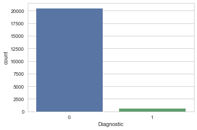

```python
sns.countplot(x=palu['Diagnostic'], data=palu)
plt.show()
```

```python
paluu=pd.DataFrame(palu, columns = ['PPOIDS', 'TEMPERATURE', 'S_M8_APPETIT', 'S_FATIGUE', 'S_ARTHRALGI', 'S_T_DIGESTIF', 'S_VERTIGE', 'S_FRISSON', 'S_MYALGIE', 'S_DABDO', 'S_VOMISS', 'S_NAUSEE', 'S_CEPHALE', 'S_FIEVRE','TDR'])
```

```python
paluu.head()
```

|  | PPOIDS | TEMPERATURE | S_M8_APPETIT | S_FATIGUE | S_ARTHRALGI | S_T_DIGESTIF | S_VERTIGE | S_FRISSON | S_MYALGIE | S_DABDO | S_VOMISS | S_NAUSEE | S_CEPHALE | S_FIEVRE | TDR |
| --- | --- | --- | --- | --- | --- | --- | --- | --- | --- | --- | --- | --- | --- | --- | --- |
| 0 | 74 | 37 | 0 | 0 | 0 | 0 | 0 | 0 | 0 | 0 | 1 | 0 | 0 | 0 | 9 |
| 1 | 113 | 37 | 0 | 0 | 0 | 0 | 0 | 1 | 0 | 0 | 0 | 0 | 1 | 0 | 2 |
| 2 | 98 | 37 | 0 | 0 | 0 | 0 | 0 | 0 | 0 | 0 | 0 | 0 | 1 | 1 | 9 |
| 3 | 85 | 37 | 0 | 0 | 0 | 0 | 0 | 0 | 0 | 0 | 0 | 0 | 0 | 0 | 2 |
| 4 | 71 | 37 | 0 | 0 | 0 | 0 | 0 | 0 | 0 | 0 | 0 | 0 | 0 | 0 | 9 |

```python
paluu.info()
```

```
<class 'pandas.core.frame.DataFrame'>
RangeIndex: 21083 entries, 0 to 21082
Data columns (total 15 columns):
PPOIDS          21083 non-null int64
TEMPERATURE     21083 non-null int64
S_M8_APPETIT    21083 non-null int64
S_FATIGUE       21083 non-null int64
S_ARTHRALGI     21083 non-null int64
S_T_DIGESTIF    21083 non-null int64
S_VERTIGE       21083 non-null int64
S_FRISSON       21083 non-null int64
S_MYALGIE       21083 non-null int64
S_DABDO         21083 non-null int64
S_VOMISS        21083 non-null int64
S_NAUSEE        21083 non-null int64
S_CEPHALE       21083 non-null int64
S_FIEVRE        21083 non-null int64
TDR             21083 non-null int64
dtypes: int64(15)
memory usage: 2.4 MB
```

Verifions l'independances des données

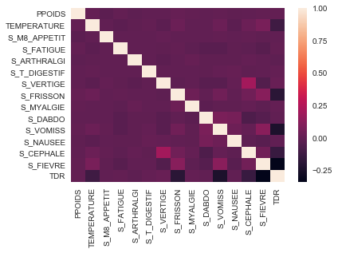

```python
sns.heatmap(paluu.corr())
plt.show()
```

On remarque ques les données semblent etre indépendantes

Notre variable cible est l'attribut 'Diagnostic' qui permettra de dire si un patient est atteint de paludisme ou non Etant donné que le Diagnostic est le resultat des signes symptomes plus l'examen medical nootre prédiction sera basée sur les attributs 'PPOIDS', 'TEMPERATURE', 'S_M8_APPETIT', 'S_FATIGUE', 'S_ARTHRALGI', 'S_T_DIGESTIF', 'S_VERTIGE', 'S_FRISSON', 'S_MYALGIE', 'S_DABDO', 'S_VOMISS', 'S_NAUSEE', 'S_CEPHALE', 'S_FIEVRE','TDR'

```python
# Nous séparons notre jeu données palu en deux parties. Une partie pour entrainer X_train et un partie pour tester X_test
# Nous séparons notre variable cible en deux parties. Une partie pour entrainer y_train et une partie pour tester y_test
X = paluu
y = palu['Diagnostic']
X_train, X_test, y_train, y_test = train_test_split(X, y, random_state=0)
```

```python
X_train.shape
y_train.shape
```

```
(15812,)
```

```python
X_train.head()
```

|  | PPOIDS | TEMPERATURE | S_M8_APPETIT | S_FATIGUE | S_ARTHRALGI | S_T_DIGESTIF | S_VERTIGE | S_FRISSON | S_MYALGIE | S_DABDO | S_VOMISS | S_NAUSEE | S_CEPHALE | S_FIEVRE | TDR |
| --- | --- | --- | --- | --- | --- | --- | --- | --- | --- | --- | --- | --- | --- | --- | --- |
| 194 | 109 | 34 | 0 | 0 | 0 | 0 | 0 | 0 | 0 | 0 | 0 | 0 | 0 | 0 | 9 |
| 9889 | 118 | 37 | 0 | 0 | 0 | 0 | 0 | 0 | 0 | 0 | 0 | 0 | 0 | 0 | 9 |
| 6732 | 98 | 36 | 0 | 0 | 0 | 0 | 0 | 0 | 0 | 0 | 0 | 0 | 1 | 0 | 2 |
| 21078 | 92 | 36 | 0 | 0 | 0 | 0 | 0 | 0 | 0 | 0 | 0 | 0 | 0 | 0 | 9 |
| 9729 | 75 | 37 | 0 | 0 | 0 | 0 | 0 | 0 | 0 | 0 | 0 | 0 | 0 | 0 | 9 |

# Construction Model Regression logistique

```python
#Fit logistic regression to the training set
palu_classifier = LogisticRegression(random_state=0)
palu_classifier.fit(X_train, y_train)
```

```
LogisticRegression(C=1.0, class_weight=None, dual=False, fit_intercept=True,
          intercept_scaling=1, max_iter=100, multi_class='ovr', n_jobs=1,
          penalty='l2', random_state=0, solver='liblinear', tol=0.0001,
          verbose=0, warm_start=False)
```

# Precision

```python
#Calcule de la précision du modele
palu_pred = palu_classifier.predict(X_test)
from sklearn.metrics import confusion_matrix
confusion_matrix = confusion_matrix(y_test, palu_pred)
print(confusion_matrix)
```

```
[[5115    5]
 [ 130   21]]
```

Le résultat nous indique que nous avons 5115 + 21 prédictions correctes c'est à dire que 5136 patient ont eu un diagnostic adéquates et 130 + 5 malclassés c'est à direque 135 patients mal diagnostiqués.

```python
print('La precision de la regression logistique sur les données de test  : {:.2f}'.format(palu_classifier.score(X_test, y_test)*100))
```

```
La precision de la regression logistique sur les données de test  : 97.44
```

```python
# Calcul de la precision du recall, F-measure et support
```

```python
from sklearn.metrics import classification_report
print(classification_report(y_test, palu_pred))
```

```
             precision    recall  f1-score   support

          0       0.98      1.00      0.99      5120
          1       0.81      0.14      0.24       151

avg / total       0.97      0.97      0.97      5271
```

```python
# Courbe ROC
```

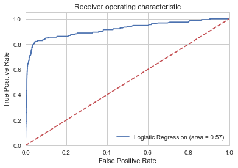

```python
from sklearn.metrics import roc_auc_score
from sklearn.metrics import roc_curve
logit_roc_auc = roc_auc_score(y_test, palu_classifier.predict(X_test))
fpr, tpr, thresholds = roc_curve(y_test, palu_classifier.predict_proba(X_test)[:,1])
plt.figure()
plt.plot(fpr, tpr, label='Logistic Regression (area = %0.2f)' % logit_roc_auc)
plt.plot([0, 1], [0, 1],'r--')
plt.xlim([0.0, 1.0])
plt.ylim([0.0, 1.05])
plt.xlabel('False Positive Rate')
plt.ylabel('True Positive Rate')
plt.title('Receiver operating characteristic')
plt.legend(loc="lower right")
plt.savefig('Log_ROC')
plt.show()
```

# Conclusion

Le score de notre prédiction est de 97,44. C'est à dire que nous pouvons dire avec une très grande Précision qu'un patient est atteint de paludisme ou non. Cependant les Données Etant très désiquibrées le score trouve ne me semble pas refleter la réalité. Aini il rusque de se produire ce qu'on appelle un vote majoritaire. C'est à dire que l'agorithme a tendence à prédire que tous les patients ne sont pas attent de paludisme car 0 est trop majoritaire Ainsi je propose d'utiliser le package imblearn de python pour éequilbrer les données et ensuite reprendre l'algorithme et comparer les scores obtenus